# Home Credit Default - Data Visualization

2020-10-14T09:10:39+09:00

# Introduction

## 대회 개요

> Many people struggle to get loans due to insufficient or non-existent credit histories. And, unfortunately, this population is often taken advantage of by untrustworthy lenders. [Home Credit](http://www.homecredit.net/) strives to broaden financial inclusion for the unbanked population by providing a positive and safe borrowing experience. In order to make sure this underserved population has a positive loan experience, Home Credit makes use of a variety of alternative data–including telco and transactional information–to predict their clients’ repayment abilities. While Home Credit is currently using various statistical and machine learning methods to make these predictions, they’re challenging Kagglers to help them unlock the full potential of their data. Doing so will ensure that clients capable of repayment are not rejected and that loans are given with a principal, maturity, and repayment calendar that will empower their clients to be successful.

## 데이터 파일 구조

- 데이터 파일 구조는 크게 2가지로 나뉠 수 있다.

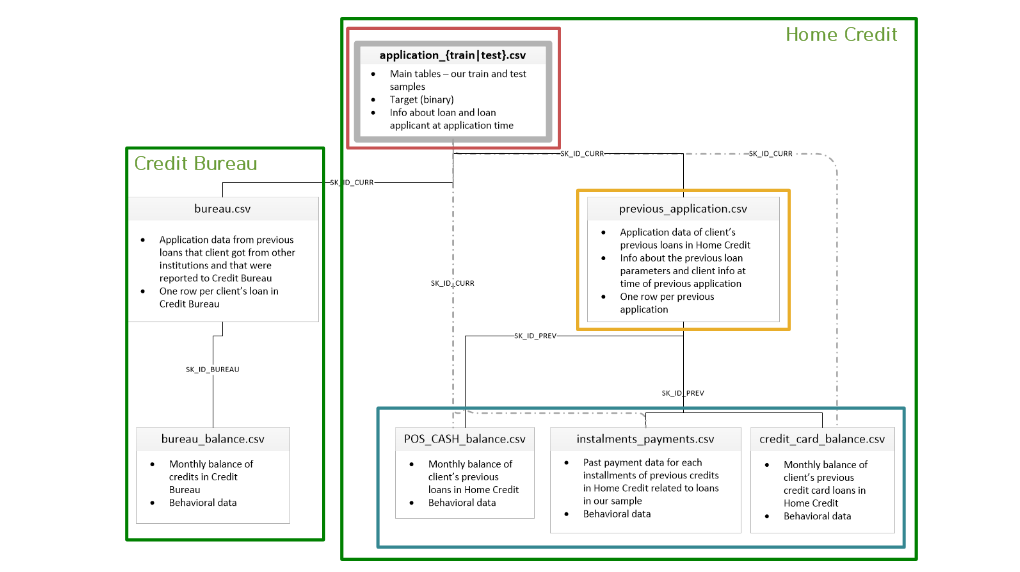

- Credit Bureau 파일 구조와 Home Credit 파일 구조로 분리할 수 있음.
- Bureau (External File)
- Home Credit (Internal File)
  - 현재 Home Credit File (Application train/test)
  - 이전 Home Credit File (Other’s)

## 평가 지표

- 제출한 파일은 예측 확률과 기존 관측 대상 사이의 [ROC Curve](http://en.wikipedia.org/wiki/Receiver_operating_characteristic)로 평가 한다.

# 분석 준비

## 패키지 불러오기

- 주요 패키지를 불러오도록 한다.

```r
library(tidyverse)
library(skimr)
library(GGally)
library(plotly)
library(viridis)
library(caret)
library(DT)
library(data.table)
library(lightgbm)
library(kableExtra)
```

## 데이터 불러오기

```r
na_strings = c("NA", "NaN", "?", "")
train = fread('data/home-credit-default-risk/application_train.csv',
              stringsAsFactors = FALSE,
              data.table = FALSE, na.strings = na_strings)

train %>% skim()
```

Data summary

| Name | Piped data |
| --- | --- |
| Number of rows | 307511 |
| Number of columns | 122 |
| _______________________ |  |
| Column type frequency: |  |
| character | 16 |
| numeric | 106 |
| ________________________ |  |
| Group variables | None |

**Variable type: character**

| skim_variable | n_missing | complete_rate | min | max | empty | n_unique | whitespace |
| --- | --- | --- | --- | --- | --- | --- | --- |
| NAME_CONTRACT_TYPE | 0 | 1.00 | 10 | 15 | 0 | 2 | 0 |
| CODE_GENDER | 0 | 1.00 | 1 | 3 | 0 | 3 | 0 |
| FLAG_OWN_CAR | 0 | 1.00 | 1 | 1 | 0 | 2 | 0 |
| FLAG_OWN_REALTY | 0 | 1.00 | 1 | 1 | 0 | 2 | 0 |
| NAME_TYPE_SUITE | 1292 | 1.00 | 6 | 15 | 0 | 7 | 0 |
| NAME_INCOME_TYPE | 0 | 1.00 | 7 | 20 | 0 | 8 | 0 |
| NAME_EDUCATION_TYPE | 0 | 1.00 | 15 | 29 | 0 | 5 | 0 |
| NAME_FAMILY_STATUS | 0 | 1.00 | 5 | 20 | 0 | 6 | 0 |
| NAME_HOUSING_TYPE | 0 | 1.00 | 12 | 19 | 0 | 6 | 0 |
| OCCUPATION_TYPE | 96391 | 0.69 | 7 | 21 | 0 | 18 | 0 |
| WEEKDAY_APPR_PROCESS_START | 0 | 1.00 | 6 | 9 | 0 | 7 | 0 |
| ORGANIZATION_TYPE | 0 | 1.00 | 3 | 22 | 0 | 58 | 0 |
| FONDKAPREMONT_MODE | 210295 | 0.32 | 13 | 21 | 0 | 4 | 0 |
| HOUSETYPE_MODE | 154297 | 0.50 | 14 | 16 | 0 | 3 | 0 |
| WALLSMATERIAL_MODE | 156341 | 0.49 | 5 | 12 | 0 | 7 | 0 |
| EMERGENCYSTATE_MODE | 145755 | 0.53 | 2 | 3 | 0 | 2 | 0 |

**Variable type: numeric**

| skim_variable | n_missing | complete_rate | mean | sd | p0 | p25 | p50 | p75 | p100 | hist |
| --- | --- | --- | --- | --- | --- | --- | --- | --- | --- | --- |
| SK_ID_CURR | 0 | 1.00 | 278180.52 | 102790.18 | 100002.00 | 189145.50 | 278202.00 | 367142.50 | 456255.00 | ▇▇▇▇▇ |
| TARGET | 0 | 1.00 | 0.08 | 0.27 | 0.00 | 0.00 | 0.00 | 0.00 | 1.00 | ▇▁▁▁▁ |
| CNT_CHILDREN | 0 | 1.00 | 0.42 | 0.72 | 0.00 | 0.00 | 0.00 | 1.00 | 19.00 | ▇▁▁▁▁ |
| AMT_INCOME_TOTAL | 0 | 1.00 | 168797.92 | 237123.15 | 25650.00 | 112500.00 | 147150.00 | 202500.00 | 117000000.00 | ▇▁▁▁▁ |
| AMT_CREDIT | 0 | 1.00 | 599026.00 | 402490.78 | 45000.00 | 270000.00 | 513531.00 | 808650.00 | 4050000.00 | ▇▂▁▁▁ |
| AMT_ANNUITY | 12 | 1.00 | 27108.57 | 14493.74 | 1615.50 | 16524.00 | 24903.00 | 34596.00 | 258025.50 | ▇▁▁▁▁ |
| AMT_GOODS_PRICE | 278 | 1.00 | 538396.21 | 369446.46 | 40500.00 | 238500.00 | 450000.00 | 679500.00 | 4050000.00 | ▇▂▁▁▁ |
| REGION_POPULATION_RELATIVE | 0 | 1.00 | 0.02 | 0.01 | 0.00 | 0.01 | 0.02 | 0.03 | 0.07 | ▇▇▃▁▁ |
| DAYS_BIRTH | 0 | 1.00 | -16037.00 | 4363.99 | -25229.00 | -19682.00 | -15750.00 | -12413.00 | -7489.00 | ▃▆▇▇▅ |
| DAYS_EMPLOYED | 0 | 1.00 | 63815.05 | 141275.77 | -17912.00 | -2760.00 | -1213.00 | -289.00 | 365243.00 | ▇▁▁▁▂ |
| DAYS_REGISTRATION | 0 | 1.00 | -4986.12 | 3522.89 | -24672.00 | -7479.50 | -4504.00 | -2010.00 | 0.00 | ▁▁▂▅▇ |
| DAYS_ID_PUBLISH | 0 | 1.00 | -2994.20 | 1509.45 | -7197.00 | -4299.00 | -3254.00 | -1720.00 | 0.00 | ▁▆▇▆▅ |
| OWN_CAR_AGE | 202929 | 0.34 | 12.06 | 11.94 | 0.00 | 5.00 | 9.00 | 15.00 | 91.00 | ▇▁▁▁▁ |
| FLAG_MOBIL | 0 | 1.00 | 1.00 | 0.00 | 0.00 | 1.00 | 1.00 | 1.00 | 1.00 | ▁▁▁▁▇ |
| FLAG_EMP_PHONE | 0 | 1.00 | 0.82 | 0.38 | 0.00 | 1.00 | 1.00 | 1.00 | 1.00 | ▂▁▁▁▇ |
| FLAG_WORK_PHONE | 0 | 1.00 | 0.20 | 0.40 | 0.00 | 0.00 | 0.00 | 0.00 | 1.00 | ▇▁▁▁▂ |
| FLAG_CONT_MOBILE | 0 | 1.00 | 1.00 | 0.04 | 0.00 | 1.00 | 1.00 | 1.00 | 1.00 | ▁▁▁▁▇ |
| FLAG_PHONE | 0 | 1.00 | 0.28 | 0.45 | 0.00 | 0.00 | 0.00 | 1.00 | 1.00 | ▇▁▁▁▃ |
| FLAG_EMAIL | 0 | 1.00 | 0.06 | 0.23 | 0.00 | 0.00 | 0.00 | 0.00 | 1.00 | ▇▁▁▁▁ |
| CNT_FAM_MEMBERS | 2 | 1.00 | 2.15 | 0.91 | 1.00 | 2.00 | 2.00 | 3.00 | 20.00 | ▇▁▁▁▁ |
| REGION_RATING_CLIENT | 0 | 1.00 | 2.05 | 0.51 | 1.00 | 2.00 | 2.00 | 2.00 | 3.00 | ▁▁▇▁▂ |
| REGION_RATING_CLIENT_W_CITY | 0 | 1.00 | 2.03 | 0.50 | 1.00 | 2.00 | 2.00 | 2.00 | 3.00 | ▁▁▇▁▂ |
| HOUR_APPR_PROCESS_START | 0 | 1.00 | 12.06 | 3.27 | 0.00 | 10.00 | 12.00 | 14.00 | 23.00 | ▁▃▇▆▁ |
| REG_REGION_NOT_LIVE_REGION | 0 | 1.00 | 0.02 | 0.12 | 0.00 | 0.00 | 0.00 | 0.00 | 1.00 | ▇▁▁▁▁ |
| REG_REGION_NOT_WORK_REGION | 0 | 1.00 | 0.05 | 0.22 | 0.00 | 0.00 | 0.00 | 0.00 | 1.00 | ▇▁▁▁▁ |
| LIVE_REGION_NOT_WORK_REGION | 0 | 1.00 | 0.04 | 0.20 | 0.00 | 0.00 | 0.00 | 0.00 | 1.00 | ▇▁▁▁▁ |
| REG_CITY_NOT_LIVE_CITY | 0 | 1.00 | 0.08 | 0.27 | 0.00 | 0.00 | 0.00 | 0.00 | 1.00 | ▇▁▁▁▁ |
| REG_CITY_NOT_WORK_CITY | 0 | 1.00 | 0.23 | 0.42 | 0.00 | 0.00 | 0.00 | 0.00 | 1.00 | ▇▁▁▁▂ |
| LIVE_CITY_NOT_WORK_CITY | 0 | 1.00 | 0.18 | 0.38 | 0.00 | 0.00 | 0.00 | 0.00 | 1.00 | ▇▁▁▁▂ |
| EXT_SOURCE_1 | 173378 | 0.44 | 0.50 | 0.21 | 0.01 | 0.33 | 0.51 | 0.68 | 0.96 | ▂▇▇▇▃ |

[output cut: 76 more lines]

```r
test = fread('data/home-credit-default-risk/application_test.csv',
              stringsAsFactors = FALSE,
              data.table = FALSE, na.strings = na_strings)

dim(test)
```

```
## [1] 48744   121
```

```r
bureau = fread('data/home-credit-default-risk/bureau.csv',
              stringsAsFactors = FALSE,
              data.table = FALSE, na.strings = na_strings)

dim(bureau)
```

```
## [1] 1716428      17
```

```r
bureau %>% skim()
```

Data summary

| Name | Piped data |
| --- | --- |
| Number of rows | 1716428 |
| Number of columns | 17 |
| _______________________ |  |
| Column type frequency: |  |
| character | 3 |
| numeric | 14 |
| ________________________ |  |
| Group variables | None |

**Variable type: character**

| skim_variable | n_missing | complete_rate | min | max | empty | n_unique | whitespace |
| --- | --- | --- | --- | --- | --- | --- | --- |
| CREDIT_ACTIVE | 0 | 1 | 4 | 8 | 0 | 4 | 0 |
| CREDIT_CURRENCY | 0 | 1 | 10 | 10 | 0 | 4 | 0 |
| CREDIT_TYPE | 0 | 1 | 8 | 44 | 0 | 15 | 0 |

**Variable type: numeric**

| skim_variable | n_missing | complete_rate | mean | sd | p0 | p25 | p50 | p75 | p100 | hist |
| --- | --- | --- | --- | --- | --- | --- | --- | --- | --- | --- |
| SK_ID_CURR | 0 | 1.00 | 278214.93 | 102938.56 | 100001.0 | 188866.8 | 278055.0 | 367426.0 | 456255 | ▇▇▇▇▇ |
| SK_ID_BUREAU | 0 | 1.00 | 5924434.49 | 532265.73 | 5000000.0 | 5463953.8 | 5926303.5 | 6385681.2 | 6843457 | ▇▇▇▇▇ |
| DAYS_CREDIT | 0 | 1.00 | -1142.11 | 795.16 | -2922.0 | -1666.0 | -987.0 | -474.0 | 0 | ▃▃▅▇▇ |
| CREDIT_DAY_OVERDUE | 0 | 1.00 | 0.82 | 36.54 | 0.0 | 0.0 | 0.0 | 0.0 | 2792 | ▇▁▁▁▁ |
| DAYS_CREDIT_ENDDATE | 105553 | 0.94 | 510.52 | 4994.22 | -42060.0 | -1138.0 | -330.0 | 474.0 | 31199 | ▁▁▇▁▁ |
| DAYS_ENDDATE_FACT | 633653 | 0.63 | -1017.44 | 714.01 | -42023.0 | -1489.0 | -897.0 | -425.0 | 0 | ▁▁▁▁▇ |
| AMT_CREDIT_MAX_OVERDUE | 1124488 | 0.34 | 3825.42 | 206031.61 | 0.0 | 0.0 | 0.0 | 0.0 | 115987185 | ▇▁▁▁▁ |
| CNT_CREDIT_PROLONG | 0 | 1.00 | 0.01 | 0.10 | 0.0 | 0.0 | 0.0 | 0.0 | 9 | ▇▁▁▁▁ |
| AMT_CREDIT_SUM | 13 | 1.00 | 354994.59 | 1149811.34 | 0.0 | 51300.0 | 125518.5 | 315000.0 | 585000000 | ▇▁▁▁▁ |
| AMT_CREDIT_SUM_DEBT | 257669 | 0.85 | 137085.12 | 677401.13 | -4705600.3 | 0.0 | 0.0 | 40153.5 | 170100000 | ▇▁▁▁▁ |
| AMT_CREDIT_SUM_LIMIT | 591780 | 0.66 | 6229.51 | 45032.03 | -586406.1 | 0.0 | 0.0 | 0.0 | 4705600 | ▇▁▁▁▁ |
| AMT_CREDIT_SUM_OVERDUE | 0 | 1.00 | 37.91 | 5937.65 | 0.0 | 0.0 | 0.0 | 0.0 | 3756681 | ▇▁▁▁▁ |
| DAYS_CREDIT_UPDATE | 0 | 1.00 | -593.75 | 720.75 | -41947.0 | -908.0 | -395.0 | -33.0 | 372 | ▁▁▁▁▇ |
| AMT_ANNUITY | 1226791 | 0.29 | 15712.76 | 325826.95 | 0.0 | 0.0 | 0.0 | 13500.0 | 118453424 | ▇▁▁▁▁ |

```r
prev = fread('data/home-credit-default-risk/previous_application.csv',
              stringsAsFactors = FALSE,
              data.table = FALSE, na.strings = na_strings)

dim(prev)
```

```
## [1] 1670214      37
```

```r
prev %>% skim()
```

Data summary

| Name | Piped data |
| --- | --- |
| Number of rows | 1670214 |
| Number of columns | 37 |
| _______________________ |  |
| Column type frequency: |  |
| character | 16 |
| numeric | 21 |
| ________________________ |  |
| Group variables | None |

**Variable type: character**

| skim_variable | n_missing | complete_rate | min | max | empty | n_unique | whitespace |
| --- | --- | --- | --- | --- | --- | --- | --- |
| NAME_CONTRACT_TYPE | 0 | 1.00 | 3 | 15 | 0 | 4 | 0 |
| WEEKDAY_APPR_PROCESS_START | 0 | 1.00 | 6 | 9 | 0 | 7 | 0 |
| FLAG_LAST_APPL_PER_CONTRACT | 0 | 1.00 | 1 | 1 | 0 | 2 | 0 |
| NAME_CASH_LOAN_PURPOSE | 0 | 1.00 | 3 | 32 | 0 | 25 | 0 |
| NAME_CONTRACT_STATUS | 0 | 1.00 | 7 | 12 | 0 | 4 | 0 |
| NAME_PAYMENT_TYPE | 0 | 1.00 | 3 | 41 | 0 | 4 | 0 |
| CODE_REJECT_REASON | 0 | 1.00 | 2 | 6 | 0 | 9 | 0 |
| NAME_TYPE_SUITE | 820405 | 0.51 | 6 | 15 | 0 | 7 | 0 |
| NAME_CLIENT_TYPE | 0 | 1.00 | 3 | 9 | 0 | 4 | 0 |
| NAME_GOODS_CATEGORY | 0 | 1.00 | 3 | 24 | 0 | 28 | 0 |
| NAME_PORTFOLIO | 0 | 1.00 | 3 | 5 | 0 | 5 | 0 |
| NAME_PRODUCT_TYPE | 0 | 1.00 | 3 | 7 | 0 | 3 | 0 |
| CHANNEL_TYPE | 0 | 1.00 | 5 | 26 | 0 | 8 | 0 |
| NAME_SELLER_INDUSTRY | 0 | 1.00 | 3 | 20 | 0 | 11 | 0 |
| NAME_YIELD_GROUP | 0 | 1.00 | 3 | 10 | 0 | 5 | 0 |
| PRODUCT_COMBINATION | 346 | 1.00 | 4 | 30 | 0 | 17 | 0 |

**Variable type: numeric**

| skim_variable | n_missing | complete_rate | mean | sd | p0 | p25 | p50 | p75 | p100 | hist |
| --- | --- | --- | --- | --- | --- | --- | --- | --- | --- | --- |
| SK_ID_PREV | 0 | 1.00 | 1923089.14 | 532597.96 | 1000001.00 | 1461857.25 | 1923110.50 | 2384279.75 | 2845382.0 | ▇▇▇▇▇ |
| SK_ID_CURR | 0 | 1.00 | 278357.17 | 102814.82 | 100001.00 | 189329.00 | 278714.50 | 367514.00 | 456255.0 | ▇▇▇▇▇ |
| AMT_ANNUITY | 372235 | 0.78 | 15955.12 | 14782.14 | 0.00 | 6321.78 | 11250.00 | 20658.42 | 418058.1 | ▇▁▁▁▁ |
| AMT_APPLICATION | 0 | 1.00 | 175233.86 | 292779.76 | 0.00 | 18720.00 | 71046.00 | 180360.00 | 6905160.0 | ▇▁▁▁▁ |
| AMT_CREDIT | 1 | 1.00 | 196114.02 | 318574.62 | 0.00 | 24160.50 | 80541.00 | 216418.50 | 6905160.0 | ▇▁▁▁▁ |
| AMT_DOWN_PAYMENT | 895844 | 0.46 | 6697.40 | 20921.50 | -0.90 | 0.00 | 1638.00 | 7740.00 | 3060045.0 | ▇▁▁▁▁ |
| AMT_GOODS_PRICE | 385515 | 0.77 | 227847.28 | 315396.56 | 0.00 | 50841.00 | 112320.00 | 234000.00 | 6905160.0 | ▇▁▁▁▁ |
| HOUR_APPR_PROCESS_START | 0 | 1.00 | 12.48 | 3.33 | 0.00 | 10.00 | 12.00 | 15.00 | 23.0 | ▁▃▇▆▁ |
| NFLAG_LAST_APPL_IN_DAY | 0 | 1.00 | 1.00 | 0.06 | 0.00 | 1.00 | 1.00 | 1.00 | 1.0 | ▁▁▁▁▇ |
| RATE_DOWN_PAYMENT | 895844 | 0.46 | 0.08 | 0.11 | 0.00 | 0.00 | 0.05 | 0.11 | 1.0 | ▇▁▁▁▁ |
| RATE_INTEREST_PRIMARY | 1664263 | 0.00 | 0.19 | 0.09 | 0.03 | 0.16 | 0.19 | 0.19 | 1.0 | ▇▁▁▁▁ |
| RATE_INTEREST_PRIVILEGED | 1664263 | 0.00 | 0.77 | 0.10 | 0.37 | 0.72 | 0.84 | 0.85 | 1.0 | ▁▁▅▇▁ |
| DAYS_DECISION | 0 | 1.00 | -880.68 | 779.10 | -2922.00 | -1300.00 | -581.00 | -280.00 | -1.0 | ▂▁▂▃▇ |
| SELLERPLACE_AREA | 0 | 1.00 | 313.95 | 7127.44 | -1.00 | -1.00 | 3.00 | 82.00 | 4000000.0 | ▇▁▁▁▁ |
| CNT_PAYMENT | 372230 | 0.78 | 16.05 | 14.57 | 0.00 | 6.00 | 12.00 | 24.00 | 84.0 | ▇▂▁▁▁ |
| DAYS_FIRST_DRAWING | 673065 | 0.60 | 342209.86 | 88916.12 | -2922.00 | 365243.00 | 365243.00 | 365243.00 | 365243.0 | ▁▁▁▁▇ |
| DAYS_FIRST_DUE | 673065 | 0.60 | 13826.27 | 72444.87 | -2892.00 | -1628.00 | -831.00 | -411.00 | 365243.0 | ▇▁▁▁▁ |
| DAYS_LAST_DUE_1ST_VERSION | 673065 | 0.60 | 33767.77 | 106857.03 | -2801.00 | -1242.00 | -361.00 | 129.00 | 365243.0 | ▇▁▁▁▁ |
| DAYS_LAST_DUE | 673065 | 0.60 | 76582.40 | 149647.42 | -2889.00 | -1314.00 | -537.00 | -74.00 | 365243.0 | ▇▁▁▁▂ |
| DAYS_TERMINATION | 673065 | 0.60 | 81992.34 | 153303.52 | -2874.00 | -1270.00 | -499.00 | -44.00 | 365243.0 | ▇▁▁▁▂ |
| NFLAG_INSURED_ON_APPROVAL | 673065 | 0.60 | 0.33 | 0.47 | 0.00 | 0.00 | 0.00 | 1.00 | 1.0 | ▇▁▁▁▃ |

# 주요 변수 시각화

## Target

- 우선 Target Variable의 데이터를 확인해본다.
- 먼저 데이터 요약을 해보자.

```r
train %>%
  group_by(TARGET) %>%
  summarise(Count = n())
```

```
## # A tibble: 2 × 2
##   TARGET  Count
##    <int>  <int>
## 1      0 282686
## 2      1  24825
```

- 전체적인 비율을 구해본다.

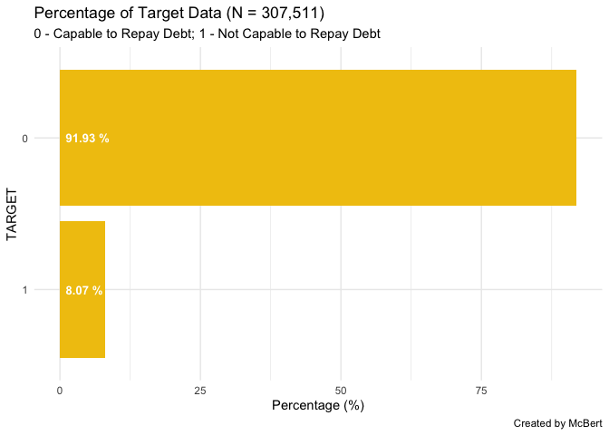

```r
# fillColor = "#FFA07A"
# fillColor2 = "#F1C40F"
# fillColorLightCoral = "#F08080"

train %>%
  group_by(TARGET) %>%
  summarise(Count = n() / nrow(train) * 100) %>%
  arrange(desc(Count)) %>%
  ungroup() %>%
  mutate(TARGET = reorder(TARGET, Count)) %>%
  ggplot(aes(x = TARGET, y = Count)) +
    geom_bar(stat = "identity", fill = "#F1C40F") +
    geom_text(aes(x = TARGET, y = 1, label = paste0(round(Count, 2), " %")),
              hjust = 0, vjust = .5, size = 3.5, colour = "white", fontface = "bold") +
    coord_flip() +
    labs(x = "TARGET",
         y = "Percentage (%)",
         title = "Percentage of Target Data (N = 307,511)",
         subtitle = "0 - Capable to Repay Debt; 1 - Not Capable to Repay Debt",
         caption = "Created by McBert") +
    theme_minimal()
```

## Gender

- 이번에는 Gender의 숫자를 구해본다.

```r
train %>%
  group_by(CODE_GENDER) %>%
  summarise(Count = n())
```

```
## # A tibble: 3 × 2
##   CODE_GENDER  Count
##   <chr>        <int>
## 1 F           202448
## 2 M           105059
## 3 XNA              4
```

```r
train %>%
  group_by(CODE_GENDER, TARGET) %>%
  summarise(Count = n())
```

```
## # A tibble: 5 × 3
## # Groups:   CODE_GENDER [3]
##   CODE_GENDER TARGET  Count
##   <chr>        <int>  <int>
## 1 F                0 188278
## 2 F                1  14170
## 3 M                0  94404
## 4 M                1  10655
## 5 XNA              0      4
```

- 이번에는 시각화를 해본다.

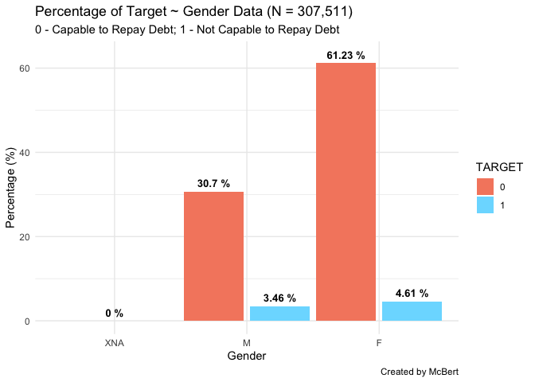

```r
train %>%
  group_by(CODE_GENDER, TARGET) %>%
  summarise(Count = n() / nrow(train) * 100) %>%
  arrange(desc(Count)) %>%
  ungroup() %>%
  mutate(CODE_GENDER = reorder(CODE_GENDER, Count),
         TARGET = as.factor(TARGET)) %>%
  ggplot(aes(x = CODE_GENDER, y = Count, fill = TARGET)) +
    geom_bar(stat = "identity", position = position_dodge(width = 1)) +
    geom_text(aes(x = CODE_GENDER, y = Count + 2, label = paste0(round(Count, 2), " %"), group = TARGET),
              position = position_dodge(width = 1), size = 3.5, colour = "black", fontface = "bold") +
    labs(x = "Gender",
         y = "Percentage (%)",
         title = "Percentage of Target ~ Gender Data (N = 307,511)",
         subtitle = "0 - Capable to Repay Debt; 1 - Not Capable to Repay Debt",
         caption = "Created by McBert") +
    scale_fill_manual(values = c("#F5896E", "#7BDCFF")) +
    theme_minimal()
```

## AMT CREDIT

- 이번에는 대출 잔액을 확인해본다.

```r
summary(train$AMT_CREDIT)
```

```
##    Min. 1st Qu.  Median    Mean 3rd Qu.    Max.
##   45000  270000  513531  599026  808650 4050000
```

- 데이터의 분포도를 그려보도록 한다.

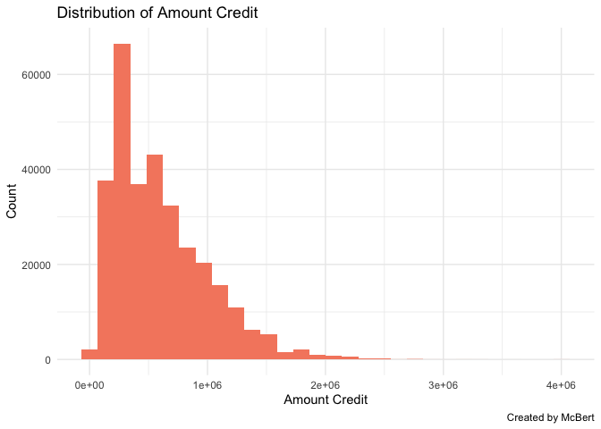

```r
train %>%
  ggplot(aes(x = AMT_CREDIT)) +
  geom_histogram(bins = 30, fill = "#F5896E") +
  labs(x = "Amount Credit",
       y = "Count",
       title = "Distribution of Amount Credit",
       caption = "Created by McBert") +
  theme_minimal()
```

- 이상치를 제거하도록 한다. + 상위 2.5%는 제거하도록 한다.

```r
upper_threshold = quantile(train$AMT_CREDIT, 0.975)
cat("Top 2.5% threshold is:", upper_threshold)
```

```
## Top 2.5% threshold is: 1574532
```

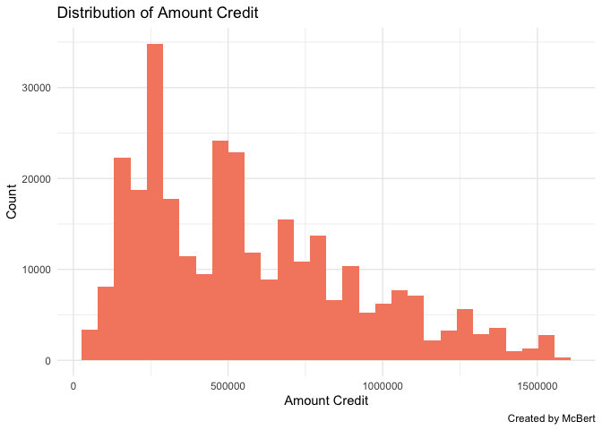

```r
train %>%
  filter(AMT_CREDIT <= upper_threshold) %>%
  ggplot(aes(x = AMT_CREDIT)) +
  geom_histogram(bins = 30, fill = "#F5896E") +
  labs(x = "Amount Credit",
       y = "Count",
       title = "Distribution of Amount Credit",
       caption = "Created by McBert") +
  theme_minimal()
```

## TARGET ~ Age, Gender, Status

- 이번에는 조건문을 활용하여 데이터를 요약하고, 시각화를 진행해본다.

```r
train$DAYS_BIRTH[1:5]
```

```
## [1]  -9461 -16765 -19046 -19005 -19932
```

```r
train$CODE_GENDER[1:5]
```

```
## [1] "M" "F" "M" "F" "M"
```

```r
table(train$CNT_FAM_MEMBERS)
```

```
##
##      1      2      3      4      5      6      7      8      9     10     11
##  67847 158357  52601  24697   3478    408     81     20      6      3      1
##     12     13     14     15     16     20
##      2      1      2      1      2      2
```

```r
table(train$NAME_FAMILY_STATUS)
```

```
##
##       Civil marriage              Married            Separated
##                29775               196432                19770
## Single / not married              Unknown                Widow
##                45444                    2                16088
```

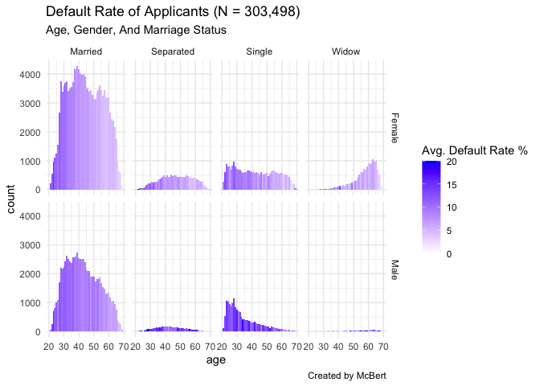

```r
train %>%
  filter(!is.na(TARGET), CODE_GENDER != "XNA", CNT_FAM_MEMBERS <= 4) %>% # nrow() ~ 303498
  group_by(age = -round(DAYS_BIRTH/365, 0),
           gender = ifelse(CODE_GENDER == "M", "Male", "Female"),
           status = ifelse(NAME_FAMILY_STATUS == "Civil marriage", "Married",
                           ifelse(NAME_FAMILY_STATUS == "Single / not married", "Single", as.character(NAME_FAMILY_STATUS)))) %>% # select(NAME_FAMILY_STATUS)
  summarise(count = n(),
            AVG_CREDIT = mean(AMT_CREDIT),
            AVG_TARGET = mean(TARGET)) %>%
  mutate(AVG_TARGET = pmin(pmax(AVG_TARGET, 0.00), 0.20) * 100) %>%
  ggplot(aes(x = age, y = count, fill = AVG_TARGET)) +
    geom_histogram(stat = "identity", width = 1) +
    facet_grid(gender ~ status) +
    scale_fill_gradient("Avg. Default Rate %", low = "white", high = "blue") +
    labs(title = "Default Rate of Applicants (N = 303,498)",
         subtitle = "Age, Gender, And Marriage Status",
         caption = "Created by McBert") +
    theme_minimal()
```

- 상대적으로 Single, Male 그룹이 다른 그룹보다 Default 비율이 높았다. - 또한, 상대적으로 연령대가 낮을수록 Default 비율이 높았다.

## Dept/Incomes Ratio %

- Dept의 비율이 높으면 높으수록 Default 비율도 높을 것으로 예상할 수 있다. 실제로 그런지 확인해본다.

```r
library(scales)
```

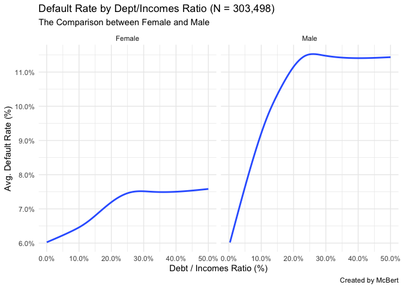

```r
train %>%
  filter(!is.na(TARGET), CODE_GENDER != "XNA", CNT_FAM_MEMBERS <= 4) %>%
  mutate(CODE_GENDER = ifelse(CODE_GENDER == "M", "Male", "Female"),
         DEPT_INCOMES_RATIO = AMT_ANNUITY/AMT_INCOME_TOTAL) %>%
  select(CODE_GENDER, DEPT_INCOMES_RATIO, TARGET) %>%
  ggplot(aes(x = DEPT_INCOMES_RATIO, y = TARGET)) +
    geom_smooth(se = FALSE) +
    scale_x_continuous(name = "Debt / Incomes Ratio (%)",
                       limits = c(0, 0.5),
                       labels = percent_format(accuracy = 0.1)) +
    # coord_cartesian(ylim=c(0.00, 0.15)) +
    scale_y_continuous(name = "Avg. Default Rate (%)",
                       breaks = seq(0, 1, 0.01),
                       labels = percent_format(accuracy = 0.1)) +
    facet_grid(~ CODE_GENDER) +
    labs(title = "Default Rate by Dept/Incomes Ratio (N = 303,498)",
         subtitle = "The Comparison between Female and Male",
         caption = "Created by McBert") +
    theme_minimal()
```

## (과제) 개인별 시각화 인사이트 찾기

- 지금까지의 작성방법을 토대로 다양하게 시각화를 작성해본다.